# Week 1 seminar (complete)

Author

Joshua Loftus

```r
library(tidyverse) # should've already install.packages("tidyverse")
library(gapminder) # might need to install.packages("gapminder")
library(broom)     # might need to install.packages("broom")
theme_set(theme_minimal())
```

## Before the seminar

The lecture proved one result, which you redo with the slides closed (exercise 2), and stated another without proof, which you prove (exercise 3). Do all three exercises on paper before the seminar; the seminar’s problems are variations on exercise 2. You may use, without proof, two facts from ST102: for independent random variables the expectation of a product is the product of the expectations, and the variance of a sum is the sum of the variances.

**WarningHints**

Exercises 2 and 3 have hints, collapsed below them. Do not open a hint unless you have been stuck for at least a few minutes, and open them in order. Exercise 2’s proof is on the lecture slides. Solutions are shown in the seminar if you ask.

**Exercise 1 (the competition).** Without looking anything up: for the `gapminder` data, write down the four parts of a prediction competition (the unit, the inputs and outcome, the score, how the held-out set is chosen). Then, for each input: would you have it at the moment you need the prediction, for a country whose life expectancy you don’t know? “All of them” is an acceptable answer if you can say why.

**TipReveal answer**

Unit: a country in one year (2007). Inputs: `gdpPercap`, `pop`, `continent` (`year` is constant, so it carries nothing). Outcome: `lifeExp`. Score: mean squared error on the held-out countries (a choice; the classification week asks who made it). Held-out set: a random subset of countries, chosen once, never used for fitting. All of the inputs are available in principle, and a justified “all of them” is a full answer; the sharper point is that `lifeExp` is built from the same national statistics as `pop`, so “we don’t know life expectancy but we know population exactly” is a fiction to keep in mind.

**Exercise 2 (bias–variance decomposition).** The lecture proved this one. Close the slides and prove it again. The training data are $y_i = f^\star(x_i) + \varepsilon_i$, $i = 1, \ldots, n$, with the inputs fixed and the noise terms independent, each with mean $0$ and variance $\sigma^2$. A new outcome at the input $x_0$ is $Y_0 = f^\star(x_0) + \varepsilon_0$, where $\varepsilon_0$ has the same mean and variance and is independent of the training noise. The prediction is $\hat f_k(x_0) = \frac1k \sum_{l=1}^k y_{(l)}$, the average outcome of the $k$ training points nearest to $x_0$. Show that
$$\mathbb E\big[(Y_0 - \hat f_k(x_0))^2\big] = \sigma^2 + \Big[f^\star(x_0) - \tfrac{1}{k}\textstyle\sum_{l=1}^k f^\star(x_{(l)})\Big]^2 + \frac{\sigma^2}{k}.$$
Independence is used twice. Where?

**NoteHint 1**

Write $Y_0 - \hat f_k(x_0) = \varepsilon_0 + \big[f^\star(x_0) - \hat f_k(x_0)\big]$. Square it and take expectations: three terms.

**NoteHint 2**

The middle term is $2\,\mathbb E[\varepsilon_0\, g]$ with $g = f^\star(x_0) - \hat f_k(x_0)$, a function of the training data. What does independence let you do to the expectation of a product?

**NoteHint 3**

You are left with $\sigma^2 + \mathbb E[Z^2]$ for $Z = f^\star(x_0) - \hat f_k(x_0)$. For any random variable, $\mathbb E[Z^2] = (\mathbb E Z)^2 + \mathrm{Var}(Z)$.

**NoteHint 4**

Write $\hat f_k(x_0)$ out in terms of $f^\star$ and the noise. Which parts of it are random? Then take its mean and its variance.

**TipReveal solution**

The lecture’s five lines. Hint 1:
$$\mathbb E\big[(Y_0 - \hat f_k(x_0))^2\big] = \mathbb E[\varepsilon_0^2] + 2\,\mathbb E\big[\varepsilon_0\,(f^\star(x_0) - \hat f_k(x_0))\big] + \mathbb E\big[(f^\star(x_0) - \hat f_k(x_0))^2\big].$$
Hint 2: $\varepsilon_0$ is independent of the training noise, so of $\hat f_k(x_0)$, and has mean $0$. The middle term is $2\,\mathbb E[\varepsilon_0]\,\mathbb E[f^\star(x_0) - \hat f_k(x_0)] = 0$, and $\mathbb E[\varepsilon_0^2] = \sigma^2$. Hint 3, with $Z = f^\star(x_0) - \hat f_k(x_0)$: subtracting a random variable from a constant keeps its variance, so
$$\mathbb E[Z^2] = \big[f^\star(x_0) - \mathbb E\hat f_k(x_0)\big]^2 + \mathrm{Var}\big(\hat f_k(x_0)\big).$$
Hint 4: **with the inputs fixed, the $k$ nearest training points are the same $k$ points whatever the noise turns out to be**. So $\hat f_k(x_0) = \frac1k\sum_l \big[f^\star(x_{(l)}) + \varepsilon_{(l)}\big]$ is a fixed number plus an average of $k$ independent noise terms: its mean is $\frac1k\sum_l f^\star(x_{(l)})$ and its variance is $\frac{1}{k^2}\cdot k\sigma^2 = \sigma^2/k$. Substitute.

Independence is used twice: between $\varepsilon_0$ and the training noise (the cross term vanishes), and among the neighbors’ noise terms (the variance of their average is $\sigma^2/k$). Problems 3(b) and 2(b) show what happens when each one fails.

Common errors: treating the set of neighbors as random; dropping the cross term without saying why it is zero; $\mathrm{Var}(\hat f_k(x_0)) = \sigma^2$ or $\sigma^2/k^2$.

**Exercise 3 (distance concentration).** The lecture stated this one without proof. Let $X$ and $X'$ be independent $N(0, I_d)$ vectors and let $W = \|X - X'\|^2/2d$. You may use that a standard normal $Z$ has $\mathbb E Z^4 = 3$.

1. Show that $\mathbb E W = 1$ and $\mathrm{Var}(W) = 2/d$.
2. Deduce that $\Pr(|W - 1| > \varepsilon) \le 2/(d\varepsilon^2)$ for every $\varepsilon > 0$.
3. Now take a query point and $n - 1$ other points, all independent $N(0, I_d)$. Show that with probability at least $1 - 2(n-1)/(d\varepsilon^2)$, every one of the $n - 1$ squared distances from the query lies between $2d(1 - \varepsilon)$ and $2d(1 + \varepsilon)$. The $n - 1$ distances are not independent of each other. Why not, and why does your argument not need them to be?

**NoteHint 1**

Coordinate $j$ of $X - X'$ is a difference of two independent standard normals. What is its distribution? Write it as a multiple of a standard normal $Z_j$.

**NoteHint 2**

Then $W = \frac1d \sum_{j=1}^d Z_j^2$, an average of $d$ independent terms. Find the mean and the variance of one term; problem 2(a) does the rest.

**NoteHint 3**

Part (b) is Chebyshev’s inequality: $\Pr(|W - \mathbb E W| > \varepsilon) \le \mathrm{Var}(W)/\varepsilon^2$.

**NoteHint 4**

For (c): “some distance falls outside the range” is a union of $n - 1$ events. How large can the probability of a union be?

**TipReveal solution**

1. $X_j - X'_j \sim N(0, 2)$, so $X_j - X'_j = \sqrt 2\, Z_j$ with $Z_1, \ldots, Z_d$ independent standard normals, and $\|X - X'\|^2 = 2\sum_j Z_j^2$. So $W = \frac1d\sum_j Z_j^2$. Each $Z_j^2$ has mean $1$ and variance $\mathbb E Z_j^4 - 1 = 2$. An average of $d$ independent terms keeps the mean and divides the variance by $d$: $\mathbb E W = 1$ and $\mathrm{Var}(W) = 2/d$.
2. Chebyshev, with the mean and variance from (a).
3. Let $W_i$ be $W$ computed from the query and point $i$. The query and point $i$ are two independent $N(0, I_d)$ vectors, so (b) holds for each $W_i$. **The probability of a union is at most the sum of the probabilities, whether or not the events are independent**:
   $$\Pr\big(\text{some } |W_i - 1| > \varepsilon\big) \le \sum_{i=1}^{n-1} \Pr\big(|W_i - 1| > \varepsilon\big) \le \frac{2(n-1)}{d\varepsilon^2}.$$
   Otherwise every squared distance $2dW_i$ lies between $2d(1 - \varepsilon)$ and $2d(1 + \varepsilon)$. The $W_i$ are dependent because they share the query point: a query far from the origin is far from all the others at once.

For $n$ fixed and $d$ large, the nearest of the $n - 1$ points is about as far away as the farthest, so “nearest” says little. The bound itself is loose, because Chebyshev uses nothing but the variance: with $n = 500$ and $\varepsilon = 0.1$ it is below $1$ only for $d$ above about $100{,}000$, while the lecture’s histograms are already narrow at $d = 100$.

Common errors: giving $X_j - X'_j$ variance $1$ (the variances add, to $2$); multiplying the $n - 1$ probabilities in (c) as if the distances were independent; reading (c) as a statement about small $d$.

## Problems

These four problems rebuild the pieces of the lecture’s bias–variance decomposition. They use nothing beyond first-year probability.

**Problem 1.** Let $Z$ be a random variable with mean $\mu$ and variance $\sigma^2$.

1. Show that $\mathbb E[Z^2] = \sigma^2 + \mu^2$.
2. In the lecture’s model $Y_0 = f^\star(x_0) + \varepsilon_0$, the noise has mean $0$ and variance $\sigma^2$. What is $\mathbb E[\varepsilon_0^2]$?
3. Now let $Z = f^\star(x_0) - \hat f(x_0)$, where $f^\star(x_0)$ is a fixed number and $\hat f(x_0)$ is a random predictor with mean $m$ and variance $v$. Write $\mathbb E[Z^2]$ in terms of $f^\star(x_0)$, $m$ and $v$. Which piece is a bias, and which a variance?

**NoteHint 1**

For (a), expand $(Z - \mu)^2$ inside the expectation.

**TipReveal answer**

1. $\mathrm{Var}(Z) = \mathbb E[(Z - \mu)^2] = \mathbb E[Z^2] - 2\mu\,\mathbb E[Z] + \mu^2 = \mathbb E[Z^2] - \mu^2$, so $\mathbb E[Z^2] = \sigma^2 + \mu^2$.
2. $\mathbb E[\varepsilon_0^2] = \sigma^2 + 0^2 = \sigma^2$. This is the noise term: it is there whatever the predictor does.
3. $Z$ has mean $f^\star(x_0) - m$ and variance $v$ (subtracting a random variable from a constant keeps the variance), so $\mathbb E[Z^2] = [f^\star(x_0) - m]^2 + v$. The first piece is the squared bias, the second the variance of the predictor. This is line 3 of the lecture’s proof: “add and subtract $\mathbb E \hat f(x_0)$” is part (a) applied to $Z$.

Common error: writing $\mathbb E[Z^2] = (\mathbb E Z)^2$.

**Problem 2.** Let $Y_1, \ldots, Y_k$ be independent random variables, each with variance $\sigma^2$, and let $\bar Y = \frac1k \sum_{l=1}^k Y_l$.

1. What is $\mathrm{Var}(\bar Y)$? Say where independence is used.
2. Suppose instead that $Y_1 = Y_2 = \cdots = Y_k$ (the same random variable repeated). What is $\mathrm{Var}(\bar Y)$ now? What does this say about averaging things that are not really different?

**TipReveal answer**

1. $\mathrm{Var}(\bar Y) = \frac{1}{k^2}\sum_l \mathrm{Var}(Y_l) = \frac{1}{k^2} \cdot k\sigma^2 = \sigma^2/k$. Independence (uncorrelatedness is enough) is what lets the variance of the sum be the sum of the variances: the cross terms $\mathrm{Cov}(Y_l, Y_{l'})$ vanish. This is the variance term of the bias–variance decomposition: the $k$ neighbors’ noises are independent, so averaging them divides the variance by $k$.
2. $\bar Y = Y_1$, so $\mathrm{Var}(\bar Y) = \sigma^2$: no reduction at all. Averaging only helps to the extent that the things averaged carry independent noise. (The tree-methods week returns to the in-between case, positively correlated terms, where the variance of an average is $\rho\sigma^2 + (1 - \rho)\sigma^2/k$.)

Common error: $\mathrm{Var}(\bar Y) = \sigma^2/k$ in (b) too, by applying the formula without its assumption.

**Problem 3.** In the lecture’s setting, the new outcome’s noise $\varepsilon_0$ has mean $0$ and is independent of the training data. Let $g$ be any function of the training data (for example, $g = f^\star(x_0) - \hat f_k(x_0)$).

1. Show that $\mathbb E[\varepsilon_0\, g] = 0$.
2. Give an example where $\mathbb E[\varepsilon_0] = 0$ but $\mathbb E[\varepsilon_0\, g] \neq 0$. (Think about what happens if the “new” point is one of the training points.)

**NoteHint 1**

For (a): what does independence let you do to the expectation of a product?

**TipReveal answer**

1. Independence gives $\mathbb E[\varepsilon_0\, g] = \mathbb E[\varepsilon_0]\,\mathbb E[g] = 0 \cdot \mathbb E[g] = 0$. (Mean zero plus zero correlation would also suffice, since $\mathbb E[\varepsilon_0 g] = \mathrm{Cov}(\varepsilon_0, g) + \mathbb E[\varepsilon_0]\mathbb E[g]$; independence is the assumption in force.) This is line 2 of the lecture’s proof: the cross term vanishes.
2. Take $g = \varepsilon_0$ itself: $\mathbb E[\varepsilon_0 \cdot \varepsilon_0] = \sigma^2 \neq 0$. That is what happens when the point you evaluate on is a training point: $\hat f_k(x_0)$ then contains $\varepsilon_0$, the cross term does not vanish, and the error at that point is *smaller* than the bias–variance decomposition says. With $k = 1$ it is exactly zero. So training error is not the quantity in the bias–variance decomposition. The validation week does the rest.

**Problem 4.** Five training points, one input each:

| $x$ | 1 | 2 | 4 | 7 | 8 |
| --- | --- | --- | --- | --- | --- |
| $y$ | 3 | 5 | 4 | 10 | 9 |

1. Compute the $k$-nearest-neighbor prediction at $x_0 = 3.5$ for $k = 1$, $k = 3$ and $k = 5$.
2. What is the $k = 1$ prediction at $x_0 = 4$? At $x_0 = 7$? What is the training error of the $1$-NN predictor on these five points?
3. What is the $k = 5$ predictor, as a function of $x_0$?

**TipReveal answer**

1. Distances from $3.5$: $2.5, 1.5, 0.5, 3.5, 4.5$. Nearest first: $x = 4, 2, 1, 7, 8$. So $k=1$: $4$; $k=3$: $(4 + 5 + 3)/3 = 4$; $k=5$: $(3+5+4+10+9)/5 = 6.2$.
2. At a training point the nearest neighbor is itself, so the prediction is its own outcome: $4$ at $x_0 = 4$, $10$ at $x_0 = 7$. Every residual is zero, so the training error is $0$, for any data set with distinct inputs, whatever $y$ is.
3. The mean of all five outcomes, $6.2$, for every $x_0$: the $k = n$ predictor is the baseline competitor from the lecture’s leaderboard. So $k$ runs from “copy the nearest point” to “ignore the input”; the competition is about where in between to stop.

Common error in (a): forgetting to sort the distances before taking the first $k$.

## Coding

### 1. The competition

After running `library(gapminder)` you can access the dataset. Try typing `View(gapminder)` in the Console.

Take the countries observed in 2007. Split them at random into 100 countries you may use for fitting and 42 whose life expectancy is hidden from you. (You have it, of course. Don’t look at it until the end of each part; that is the rule of the competition.)

```r
gm <- gapminder |>
  filter(year == 2007) |>
  mutate(lgdp = log10(gdpPercap))
test_id <- sample(nrow(gm), 42)
train <- gm[-test_id, ]
test <- gm[test_id, ]
```

Your split is different from your neighbor’s. Keep that in mind all the way through.

#### Create a scatterplot of the training data

`lgdp` on the horizontal axis, `lifeExp` on the vertical axis (hint: `geom_point`).

```r
# gm_scatterplot <- ggplot(train, aes(x = ____, y = ____)) + geom_point()
# gm_scatterplot
# ...
```

**TipReveal solution**

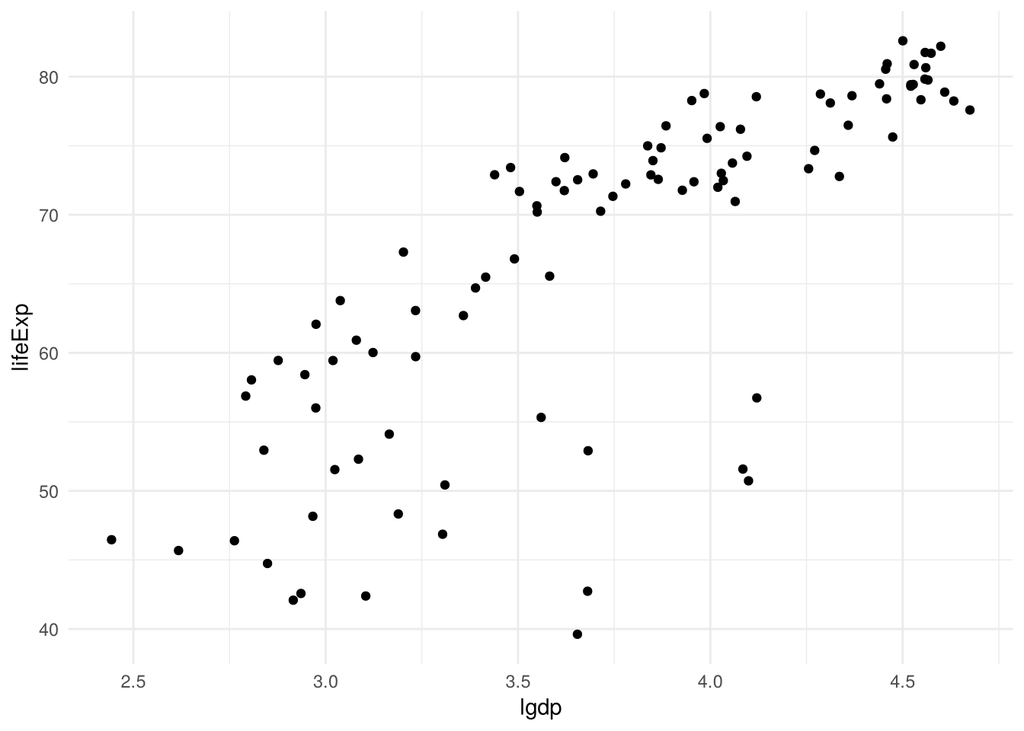

```r
gm_scatterplot <- ggplot(train, aes(x = lgdp, y = lifeExp)) +
  geom_point()
gm_scatterplot
```

#### The baseline competitor

The simplest competitor predicts the same number for every country: the training mean of `lifeExp`. Compute its mean squared error on the test set.

```r
baseline <- mean(train$lifeExp)
# mse_baseline <- mean((____ - ____)^2)
# ...
```

**TipReveal solution**

```r
baseline <- mean(train$lifeExp)
mse_baseline <- mean((test$lifeExp - baseline)^2)
mse_baseline
```

```
[1] 148.5926
```

#### A second competitor: a straight line

Fit `model_lm <- lm(lifeExp ~ lgdp, data = train)`. Get its predictions on the test countries with `predict(model_lm, newdata = ____)`, then compute the test MSE.

```r
model_lm <- lm(lifeExp ~ lgdp, data = train)
# mse_lm <- mean((____ - predict(model_lm, newdata = ____))^2)
# ...
```

**TipReveal solution**

```r
model_lm <- lm(lifeExp ~ lgdp, data = train)
mse_lm <- mean((test$lifeExp - predict(model_lm, newdata = test))^2)
mse_lm
```

```
[1] 41.97192
```

**Question 1.** How much better than the baseline is the line? Is “better” here a statement about these 42 countries or about all countries?

**TipReveal answer**

Typically the line’s test MSE is about a third of the baseline’s (across random splits the baseline is usually 115–190 and the line 35–75). It is a statement about these 42 countries: the test MSE is an average of 42 losses, and another 42 would give a different average. Part 3 measures how different.

### 2. Nearest neighbors, by hand

You may use `abs`, `order`, `mean` and a `for` loop, but not a library that does nearest neighbors for you. The point is to see the mechanism: a prediction is an average of the outcomes of the nearest training points (problem 4, in code).

**Step 1.** Write a function that takes one new input `x0`, the training inputs `x` and outcomes `y`, and a number of neighbors `k`, and returns the average outcome of the `k` training points nearest to `x0`. The distances are computed for you; you write the two lines that pick the neighbors and average their outcomes.

```r
knn_predict <- function(x0, x, y, k) {
  distances <- abs(x - x0)
  # ...
}
```

**NoteHint 1**

`order(distances)` gives the positions of the distances from smallest to largest, so its first `k` entries are the positions of the `k` nearest points.

**TipReveal solution**

```r
knn_predict <- function(x0, x, y, k) {
  distances <- abs(x - x0)
  nearest <- order(distances)[1:k]
  mean(y[nearest])
}
```

Check it on problem 4’s data first: `knn_predict(3.5, c(1, 2, 4, 7, 8), c(3, 5, 4, 10, 9), k = 3)` should give the number you computed by hand.

```r
knn_predict(3.5, c(1, 2, 4, 7, 8), c(3, 5, 4, 10, 9), k = 3)
```

```
[1] 4
```

Now on one country. For `x0 = 4` (GDP per capita of 10,000 dollars) and `k = 5`, which five training countries are used, and what is the prediction?

```r
# nearest5 <- order(abs(train$lgdp - 4))[1:5]
# train[nearest5, c("country", "gdpPercap", "lifeExp")]
# knn_predict(4, ____, ____, k = 5)
# ...
```

**TipReveal solution**

```r
nearest5 <- order(abs(train$lgdp - 4))[1:5]
train[nearest5, c("country", "gdpPercap", "lifeExp")]
```

```
# A tibble: 5 x 3
  country    gdpPercap lifeExp
  <fct>          <dbl>   <dbl>
1 Panama         9809.    75.5
2 Costa Rica     9645.    78.8
3 Lebanon       10461.    72.0
4 Uruguay       10611.    76.4
5 Bulgaria      10681.    73.0
```

```r
knn_predict(4, train$lgdp, train$lifeExp, k = 5)
```

```
[1] 75.1402
```

Checkpoint (run it; if it stops, fix step 1 before going on):

```r
stopifnot(length(knn_predict(4, train$lgdp, train$lifeExp, k = 5)) == 1,
          knn_predict(4, train$lgdp, train$lifeExp, k = 1) %in% train$lifeExp)
```

**Step 2.** Predict for all 42 test countries with `k = 5`: the loop is set up for you; fill in the one line that makes the prediction for test country `j`, then compute the test MSE.

```r
pred <- numeric(nrow(test))
for (j in seq_len(nrow(test))) {
  # pred[j] <- ____
  # ...
}
# mse_knn5 <- mean((____ - ____)^2)
# ...
```

**TipReveal solution**

```r
pred <- numeric(nrow(test))
for (j in seq_len(nrow(test))) {
  pred[j] <- knn_predict(test$lgdp[j], train$lgdp, train$lifeExp, k = 5)
}
mse_knn5 <- mean((test$lifeExp - pred)^2)
mse_knn5
```

```
[1] 58.3046
```

Checkpoint:

```r
stopifnot(length(pred) == nrow(test), all(is.finite(pred)), mse_knn5 > 0)
```

**Step 3.** Wrap step 2 in a function `knn_mse(k, newdata)` that returns the MSE of the `k`-nearest-neighbor predictor on any data frame with columns `lgdp` and `lifeExp`; the skeleton is given, you write the prediction line and the MSE line. Then compute the **training** MSE and the **test** MSE for `k = 1, 2, 3, 5, 10, 25, 50`.

**Question 2.** Before you run it: what do you expect the training MSE at `k = 1` to be, and why? Write your prediction down first.

**TipReveal answer**

Exactly zero: every training point is its own nearest neighbor (with distinct inputs). Problems 3(b) and 4(b) are the same point. It tells you nothing about the competition score; the full treatment is the validation week.

```r
knn_mse <- function(k, newdata) {
  pred <- numeric(nrow(newdata))
  for (j in seq_len(nrow(newdata))) {
    # pred[j] <- ____
    # ...
  }
  # mean((____ - ____)^2)
  # ...
}
ks <- c(1, 2, 3, 5, 10, 25, 50)
results <- tibble(
  k = ks,
  train_mse = sapply(ks, knn_mse, newdata = train),
  test_mse = sapply(ks, knn_mse, newdata = test)
)
results
```

**TipReveal solution**

```r
knn_mse <- function(k, newdata) {
  pred <- numeric(nrow(newdata))
  for (j in seq_len(nrow(newdata))) {
    pred[j] <- knn_predict(newdata$lgdp[j], train$lgdp, train$lifeExp, k = k)
  }
  mean((newdata$lifeExp - pred)^2)
}
ks <- c(1, 2, 3, 5, 10, 25, 50)
results <- tibble(
  k = ks,
  train_mse = sapply(ks, knn_mse, newdata = train),
  test_mse = sapply(ks, knn_mse, newdata = test)
)
results
```

```
# A tibble: 7 x 3
      k train_mse test_mse
  <dbl>     <dbl>    <dbl>
1     1       0       95.9
2     2      24.9     53.6
3     3      32.7     54.1
4     5      35.2     58.3
5    10      45.7     45.2
6    25      54.0     43.3
7    50      65.8     58.7
```

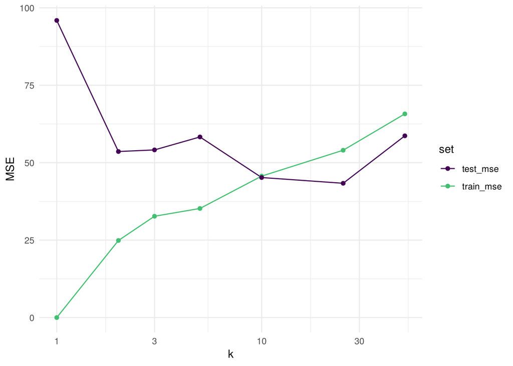

```r
results |>
  pivot_longer(-k, names_to = "set", values_to = "MSE") |>
  ggplot(aes(k, MSE, colour = set)) +
  geom_line() +
  geom_point() +
  scale_x_log10() +
  scale_colour_viridis_d(end = 0.7)
```

Checkpoint:

```r
stopifnot(nrow(results) == 7, results$train_mse[1] == 0 || any(duplicated(train$lgdp)))
```

**Question 3.** Which `k` would you submit, and what did you use to decide? You are about to report the same held-out score you chose on: is there a problem with that?

**TipReveal answer**

The `k` with the smallest test MSE. Which one that is depends on the split: across random splits the winner is 5, 10 or 25 about four times in five, occasionally 3, and `k = 1` wins on fewer than one split in a hundred. Two things are wrong. The differences among the middle `k`s are smaller than the standard error computed in part 3, so the fine ranking is mostly noise. And the held-out set was used to *choose* `k`, so its score for the chosen `k` is no longer an untouched evaluation. Both are left open for now: the protocol is the validation week, the reuse problem the regularization week.

### 3. The score is a random variable

Your test MSE is an average of 42 losses. From the split you already have, compute the 42 individual squared errors of the `k = 5` predictor, their mean (the test MSE again) and the standard error of that mean, $\text{sd(losses)}/\sqrt{42}$. (This standard error treats the 42 losses as independent draws; that is an assumption about the countries, not a fact about them.)

```r
# losses <- ____
# c(mean = mean(losses), se = ____)
# ...
```

**TipReveal solution**

```r
losses <- (test$lifeExp - pred)^2
c(mean = mean(losses), se = sd(losses) / sqrt(length(losses)))
```

```
    mean       se
58.30460 17.77255
```

**Question 4.** Compare your test MSE and its standard error with your neighbor’s. Are the two test MSEs within a standard error of each other? What made them different?

**TipReveal answer**

Usually yes, sometimes no: the standard errors on these data are typically 10–25, and the two scores differ because the two splits differ, in both which 42 countries are held out and which 100 were fitted on. The standard error treats the fitted predictor as fixed and measures only the first kind of variability, the sampling variability of an average of 42 losses; the difference between two students’ scores also carries the second. The organizer has one held-out set and one submission per competitor, so can compute only a standard error for each competitor’s own score. Whether a *gap* between two competitors is real is a further question, about the difference of their losses on the same units, which we leave open this week.

### 4. Predicting on new data

Models are supposed to capture structure in the data that corresponds to structure in the real world, and if the real world isn’t misbehaving, that structure should be somewhat stable. Suppose the relationship changed dramatically from one time period to another: then a model fit on one period would be less useful, because it might fit poorly on data from another.

Create the 1997 data, then get predictions for every 1997 country from the straight line (fitted on 2007 training countries) with the `newdata` argument, and compute the MSE.

```r
gm1997 <- gapminder |> filter(year == 1997) |> mutate(lgdp = log10(gdpPercap))
# mse_lm_1997 <- mean((gm1997$lifeExp - predict(model_lm, newdata = ____))^2)
# ...
```

**TipReveal solution**

```r
gm1997 <- gapminder |> filter(year == 1997) |> mutate(lgdp = log10(gdpPercap))
mse_lm_1997 <- mean((gm1997$lifeExp - predict(model_lm, newdata = gm1997))^2)
mse_lm_1997
```

```
[1] 34.45773
```

**Question 5.** Is it surprising how well the model does on 1997? The 1997 rows are the *same 142 countries*, ten years earlier. Has the model predicted anything new? What question does this test answer, and what question did the held-out split in part 1 answer?

**TipReveal answer**

Country-level GDP and life expectancy move slowly, so the 1997 rows are nearly the training rows again (100 of them literally the training countries); a low error mostly shows that the same countries barely moved. It does not show the model predicts new countries; the assumption it violates is independence of the test units from the training units. The held-out split in part 1 answers “can we predict a country we have not seen?”; the 1997 test answers a different, also legitimate, question: is the relationship stable over time? Both questions matter; the point is to know which one you asked. This is the lecture’s closing question 2, and next week’s opener.

## Before you leave

Compare your table from part 2 with your neighbor’s. Did the same `k` win? Write one sentence on what that means for a leaderboard, and one on what the organizer should report next to each score.

**TipReveal answer**

Different splits, often a different winner among the middle `k`s: a leaderboard ranking is a statement about one held-out set, and a gap smaller than a standard error is not established. The organizer should report a standard error with every score; how two competitors scored on the same units should be compared is left open this week.